# Linear Mixed Effects Models in R and Python

Jaehoon Lee, Jiali Luan, Guanghui Min

11/17/2018

## Topic Introduction

Beijing’s air pollution poses a big threat to the health of local residents. The PM 2.5 Index has been known as an important indication of the air quality. Exploring an effective way of predicting PM 2.5 Index will be an important step towards addressing the pollution. However, various factors such as dew point, temperature, pressure, etc. may influence PM 2.5 and the relationship between them remains unclear. Thus, it is challenging to accurately predict PM 2.5. To address this problem, linear mixed effects model is adopted to predict the response variable (ie. air quality) based on the numerous explanatory variables (meteorological records).

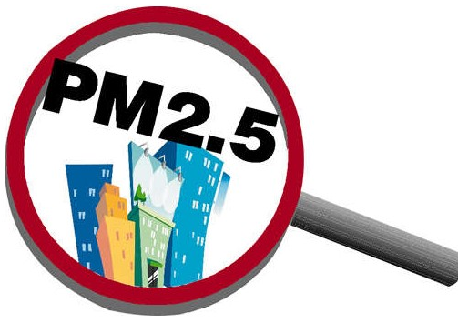

## Model Introduction

Ecological and meteorological data are often complex and messy because of the inclusion of grouping factors like gender, population, continents, and seasons. When fitting a complicated models with many parameters and observations, the data points might not be truly independent from each other. For example, all observations from a meterological dataset could be collected on the same site. Therefore, mixed models were developed to overcome such problem and let us to be able to use all of our data. A typical linear regression model takes the form
$$y = X\beta+\epsilon$$
where $X$ is the fixed effects with coefficients $\beta$. $\epsilon$ corresponds to random noise, $\epsilon \sim \mathcal{N}(0,I)$.

In a linear mixed effects model, $Z\gamma$ are being added. $Z$ corresponds to random effects with coefficicients $\gamma$. Tne model has the form
$$Y = X\beta +Z\gamma+\epsilon$$
and $\gamma \sim \mathcal{N}(0,\sigma^2I)$.

The difference between fixed and random effects is that a fixed effect is an effect that is constant for a given population, but a random effect is an effect that varies for a given population.

## Data Description

The PM 2.5 Index dataset includes 43824 observations and 12 attributes. Here is a table of the attributes’ information.

| Variable | Description | Data Type |
| --- | --- | --- |
| PM2.5 | PM2.5 concentration (ug/m^3) | numerical |
| DEWP | Dew Point | numerical |
| TEMP | Temperature | numerical |
| PRES | Pressure (hPa) | numerical |
| cbwd | Combined wind direction | categorical |
| Iws | Cumulated wind speed (m/s) | numerical |
| Is | Cumulated hours of snow | numerical |
| Ir | Cumulated hours of rain | numerical |

## Three Approaches

### Running Linear Mixed Model using package **lme4** in R

We first preprocess the data before fitting a model.

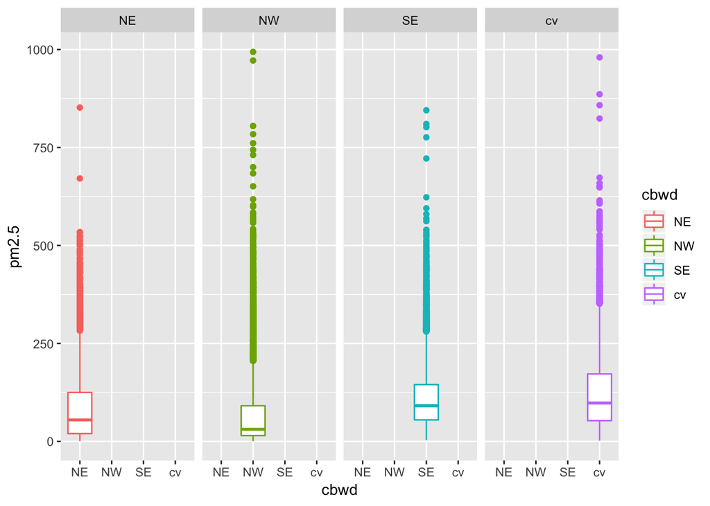

```r
AQ=read.csv("Beijing.csv")
# divide the months into four seasons
seasons = c( 'winter',
             'winter',
             rep('spring',3),
             rep('summer',3),
             rep('fall',3),
             'winter'
)
# delete the mising values
AQ = AQ %>%
  filter(!is.na(pm2.5) & pm2.5 > 0) %>%
  mutate(season=factor(month, 1:12, seasons))
# boxplot for response grouped by cbwd
qplot(cbwd, pm2.5, facets = . ~ cbwd,
      colour = cbwd, geom = "boxplot", data = AQ)
```

```r
# draw the box-cox plot
g =lm(pm2.5~., data = AQ)
#boxcox(g,plotit=T)
# the plot a log transformation for the response
AQ=
  AQ%>%
  mutate(pm2.5_log=log(pm2.5)) %>%
  filter(is.finite(pm2.5_log))
```

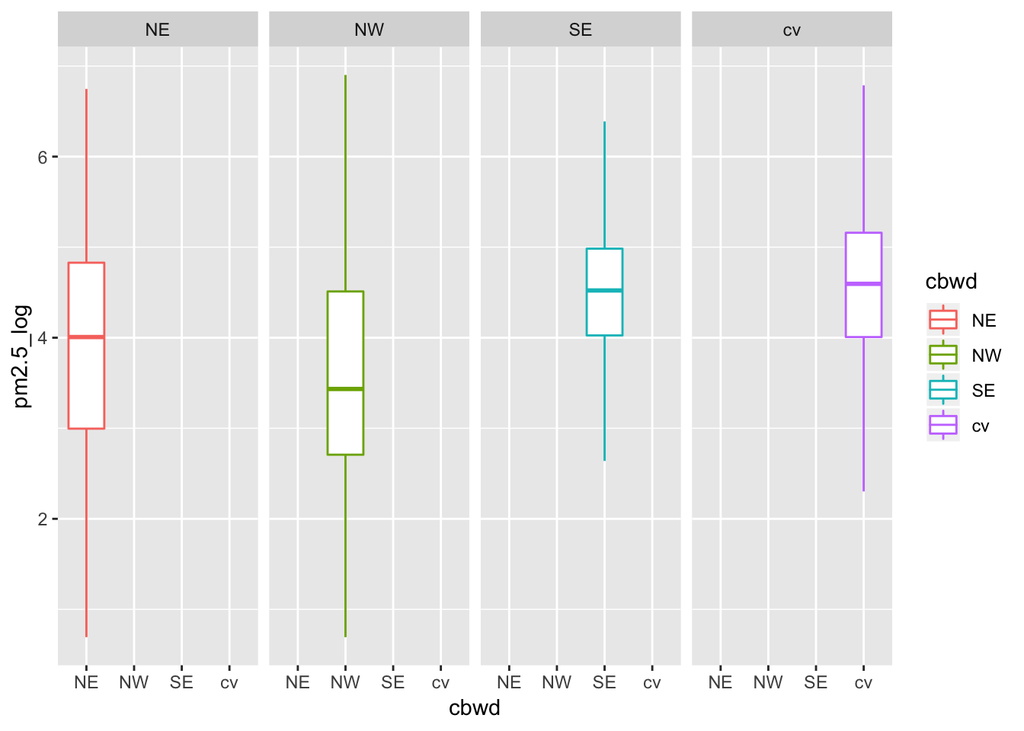

```r
qplot(cbwd, pm2.5_log, facets = . ~ cbwd,
      colour = cbwd, geom = "boxplot", data = AQ_de)
```

```r
# Multiple plot function----------------------------------------------------------------------------
#
# ggplot objects can be passed in ..., or to plotlist (as a list of ggplot objects)
# - cols:   Number of columns in layout
# - layout: A matrix specifying the layout. If present, 'cols' is ignored.
#
# If the layout is something like matrix(c(1,2,3,3), nrow=2, byrow=TRUE),
# then plot 1 will go in the upper left, 2 will go in the upper right, and
# 3 will go all the way across the bottom.
#
multiplot <- function(..., plotlist=NULL, file, cols=1, layout=NULL) {
  library(grid)

  # Make a list from the ... arguments and plotlist
  plots <- c(list(...), plotlist)

  numPlots = length(plots)

  # If layout is NULL, then use 'cols' to determine layout
  if (is.null(layout)) {
    # Make the panel
    # ncol: Number of columns of plots
    # nrow: Number of rows needed, calculated from # of cols
    layout <- matrix(seq(1, cols * ceiling(numPlots/cols)),
                     ncol = cols, nrow = ceiling(numPlots/cols))
  }

  if (numPlots==1) {
    print(plots[[1]])

  } else {
    # Set up the page
    grid.newpage()
    pushViewport(viewport(layout = grid.layout(nrow(layout), ncol(layout))))

    # Make each plot, in the correct location
    for (i in 1:numPlots) {
      # Get the i,j matrix positions of the regions that contain this subplot
      matchidx <- as.data.frame(which(layout == i, arr.ind = TRUE))

      print(plots[[i]], vp = viewport(layout.pos.row = matchidx$row,
                                      layout.pos.col = matchidx$col))
    }
  }
}
```

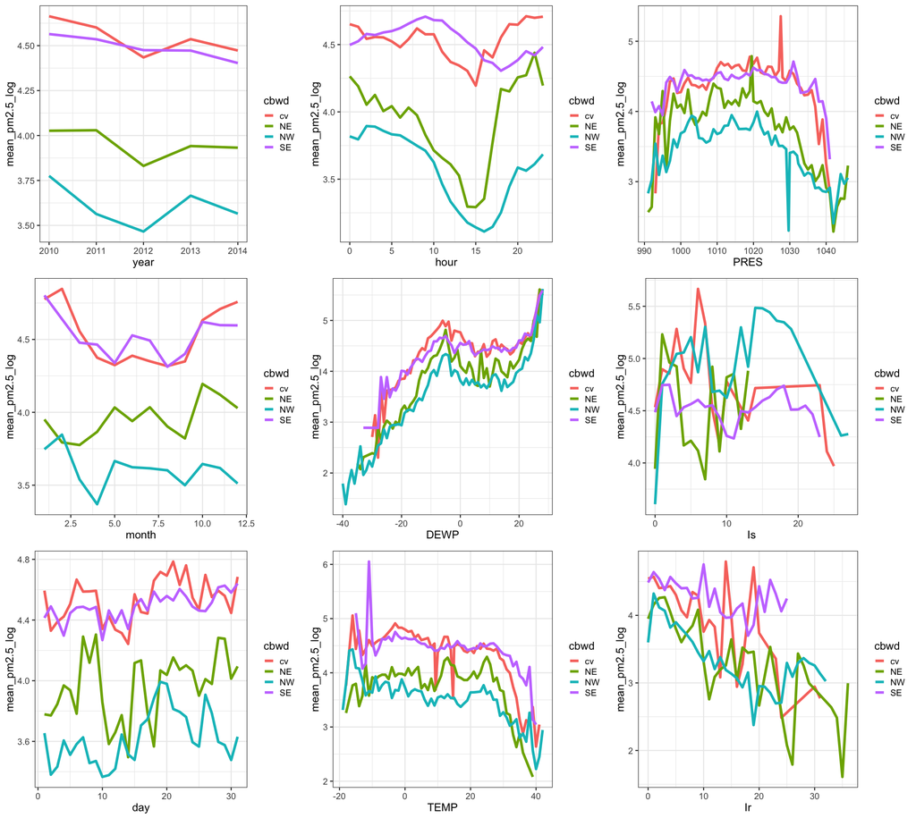

```r
# draw the plots of pm2.5_log_mean vs. predictors in cbwd groups----------------------------------
p1 = AQ_de %>%
  group_by(cbwd, year) %>%
  summarise(mean_pm2.5_log = mean(pm2.5_log)) %>%
  ggplot(aes(x=year, y=mean_pm2.5_log,
                     colour=cbwd, group=cbwd)) +
  geom_line(size=2)
p2 = AQ_de %>%
  group_by(cbwd, month) %>%
  summarise(mean_pm2.5_log = mean(pm2.5_log)) %>%
  ggplot(aes(x=month, y=mean_pm2.5_log,
             colour=cbwd, group=cbwd)) +
  geom_line(size=2)
p3 = AQ_de %>%
  group_by(cbwd, day) %>%
  summarise(mean_pm2.5_log = mean(pm2.5_log)) %>%
  ggplot(aes(x=day, y=mean_pm2.5_log,
             colour=cbwd, group=cbwd)) +
  geom_line(size=2)
p4 = AQ_de %>%
  group_by(cbwd, hour) %>%
  summarise(mean_pm2.5_log = mean(pm2.5_log)) %>%
  ggplot(aes(x=hour, y=mean_pm2.5_log,
             colour=cbwd, group=cbwd)) +
  geom_line(size=2)
p5 = AQ_de %>%
  group_by(cbwd, DEWP) %>%
  summarise(mean_pm2.5_log = mean(pm2.5_log)) %>%
  ggplot(aes(x=DEWP, y=mean_pm2.5_log,
             colour=cbwd, group=cbwd)) +
  geom_line(size=2)
p6 = AQ_de %>%
  group_by(cbwd, TEMP) %>%
  summarise(mean_pm2.5_log = mean(pm2.5_log)) %>%
  ggplot(aes(x=TEMP, y=mean_pm2.5_log,
             colour=cbwd, group=cbwd)) +
  geom_line(size=2)
p7 = AQ_de %>%
  group_by(cbwd, PRES) %>%
  summarise(mean_pm2.5_log = mean(pm2.5_log)) %>%
  ggplot(aes(x=PRES, y=mean_pm2.5_log,
             colour=cbwd, group=cbwd)) +
  geom_line(size=2)
p8 = AQ_de %>%
  group_by(cbwd, Is) %>%
  summarise(mean_pm2.5_log = mean(pm2.5_log)) %>%
  ggplot(aes(x=Is, y=mean_pm2.5_log,
             colour=cbwd, group=cbwd)) +
  geom_line(size=2)
p9 = AQ_de %>%
  group_by(cbwd, Ir) %>%
  summarise(mean_pm2.5_log = mean(pm2.5_log)) %>%
  ggplot(aes(x=Ir, y=mean_pm2.5_log,
             colour=cbwd, group=cbwd)) +
  geom_line(size=2)
# plot the figures-----------------------------------------------------------------------------------
multiplot(p1, p2, p3, p4, p5, p6, p7, p8, p9,cols=3)
```

According to the plots, we decide to choose the following model:

```r
library(lme4)
res = lmer(pm2.5_log ~ year+month+day+hour+DEWP+TEMP+PRES+Is+Ir+(1+hour+PRES|cbwd),
           REML = TRUE,
           data = AQ_de)
summary(res)
```

```
## Linear mixed model fit by REML. t-tests use Satterthwaite's method [
## lmerModLmerTest]
## Formula: pm2.5_log ~ year + month + day + hour + DEWP + TEMP + PRES +
##     Is + Ir + (1 + hour + PRES | cbwd)
##    Data: AQ_de
##
## REML criterion at convergence: 97205.7
##
## Scaled residuals:
##     Min      1Q  Median      3Q     Max
## -4.6476 -0.6715  0.0144  0.6885  4.2269
##
## Random effects:
##  Groups   Name        Variance Std.Dev. Corr
##  cbwd     (Intercept) 12.4744  3.5319
##           hour         0.3813  0.6175   0.07
##           PRES         1.9181  1.3849   0.07 1.00
##  Residual              0.6084  0.7800
## Number of obs: 41441, groups:  cbwd, 4
##
## Fixed effects:
##               Estimate Std. Error         df  t value Pr(>|t|)
## (Intercept)  3.547e+01  5.794e+00  8.041e+01    6.122 3.20e-08 ***
## year        -5.613e-03  2.731e-03  3.765e+04   -2.055   0.0399 *
## month       -2.080e-02  1.186e-03  4.137e+04  -17.536  < 2e-16 ***
## day          6.421e-03  4.369e-04  4.141e+04   14.698  < 2e-16 ***
## hour         1.210e-02  3.089e-01  1.523e-04    0.039   0.9997
## DEWP         6.006e-02  5.532e-04  4.047e+04  108.563  < 2e-16 ***
## TEMP        -7.755e-02  7.056e-04  4.064e+04 -109.904  < 2e-16 ***
## PRES        -1.895e-02  6.927e-01  1.647e-04   -0.027   0.9998
## Is          -3.513e-02  4.980e-03  3.989e+04   -7.055 1.76e-12 ***
## Ir          -8.036e-02  2.750e-03  4.135e+04  -29.219  < 2e-16 ***
## ---
## Signif. codes:  0 '***' 0.001 '**' 0.01 '*' 0.05 '.' 0.1 ' ' 1
##
## Correlation of Fixed Effects:
##       (Intr) year   month  day    hour   DEWP   TEMP   PRES   Is
## year  -0.944
## month  0.022  0.003
## day    0.001  0.001  0.006
## hour   0.022  0.000  0.000  0.000
## DEWP  -0.104  0.069 -0.239 -0.031  0.000
## TEMP   0.033 -0.103 -0.067  0.001 -0.001 -0.521
## PRES   0.021  0.000  0.000  0.000  1.000  0.000  0.001
## Is    -0.010  0.012  0.052  0.038  0.000 -0.085  0.098  0.000
## Ir    -0.015  0.012  0.004  0.003  0.000 -0.154  0.099  0.000  0.017
## convergence code: 0
## unable to evaluate scaled gradient
## Model failed to converge: degenerate  Hessian with 1 negative eigenvalues
```

We can see hour and PRES are not significant predictors. Then we test whether random effects are warranted:

```r
resb = lm(pm2.5_log ~ year+month+day+hour+DEWP+TEMP+PRES+Is+Ir, data = AQ_de)
dev1 = -2*logLik(res);dev0 = -2*logLik(resb)
devdiff = as.numeric(dev0-dev1)
dfdiff <- attr(dev1,"df")-attr(dev0,"df"); dfdiff
```

```
## [1] 6
```

```r
cat('Chi-square =', devdiff, '(df=', dfdiff,'), p =',
    pchisq(devdiff,dfdiff,lower.tail=FALSE))
```

```
## Chi-square = 5150.145 (df= 6 ), p = 0
```

and compare the BIC:

```r
BIC(resb, res) # compare the BIC of simple linear regression and linear mixed model
```

```
##      df       BIC
## resb 11 102472.79
## res  17  97386.44
```

Apparently, the random effect is significant.

### Running Linear Mixed Model using package **nlme** in R

We follow the steps to clean and process oringin data in the first part and get our dataset to fit regression. Then we use **nlme**, the default package for mixed model analysis in R, to fit the model.

```r
library(nlme)
resc=lme(pm2.5_log ~ year+month+day+hour+DEWP+TEMP+PRES+Is+Ir, random=~1+hour+PRES|cbwd,
            method = 'ML', data = AQ_de)
summary(resc)
```

```
## Linear mixed-effects model fit by maximum likelihood
##  Data: AQ_de
##        AIC      BIC    logLik
##   97430.82 97577.56 -48698.41
##
## Random effects:
##  Formula: ~1 + hour + PRES | cbwd
##  Structure: General positive-definite, Log-Cholesky parametrization
##             StdDev       Corr
## (Intercept) 6.884660e-07 (Intr) hour
## hour        3.974904e-03 0.321
## PRES        2.692867e-04 0.929  0.611
## Residual    7.832873e-01
##
## Fixed effects: pm2.5_log ~ year + month + day + hour + DEWP + TEMP + PRES +      Is + Ir
##                Value Std.Error    DF    t-value p-value
## (Intercept) 32.75997  5.532499 41428    5.92137  0.0000
## year        -0.00380  0.002740 41428   -1.38581  0.1658
## month       -0.02053  0.001190 41428  -17.25218  0.0000
## day          0.00634  0.000439 41428   14.44928  0.0000
## hour         0.01252  0.002086 41428    6.00036  0.0000
## DEWP         0.06012  0.000555 41428  108.36199  0.0000
## TEMP        -0.07805  0.000708 41428 -110.29278  0.0000
## PRES        -0.01990  0.000729 41428  -27.28603  0.0000
## Is          -0.03148  0.004987 41428   -6.31223  0.0000
## Ir          -0.07823  0.002759 41428  -28.35042  0.0000
##  Correlation:
##       (Intr) year   month  day    hour   DEWP   TEMP   PRES   Is
## year  -0.991
## month  0.022  0.003
## day    0.000  0.002  0.006
## hour  -0.010  0.012 -0.011 -0.001
## DEWP  -0.106  0.068 -0.240 -0.031  0.071
## TEMP   0.032 -0.101 -0.068  0.001 -0.075 -0.521
## PRES  -0.091 -0.039 -0.202 -0.022  0.089  0.293  0.502
## Is    -0.007  0.009  0.055  0.039 -0.006 -0.087  0.102 -0.018
## Ir    -0.014  0.010  0.004  0.004 -0.013 -0.155  0.102  0.024  0.014
##
## Standardized Within-Group Residuals:
##         Min          Q1         Med          Q3         Max
## -4.51245458 -0.68091829  0.01432061  0.69152643  4.28382111
##
## Number of Observations: 41441
## Number of Groups: 4
```

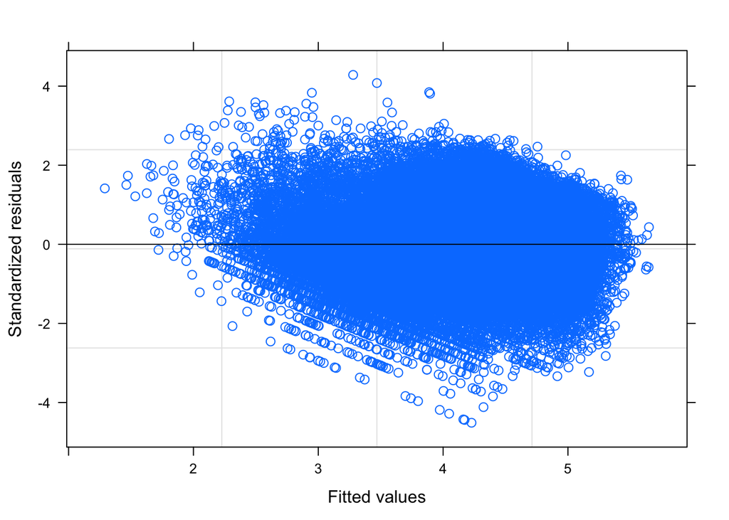

```r
# plot the residuals vs. fitted values plot
plot(resc)
```

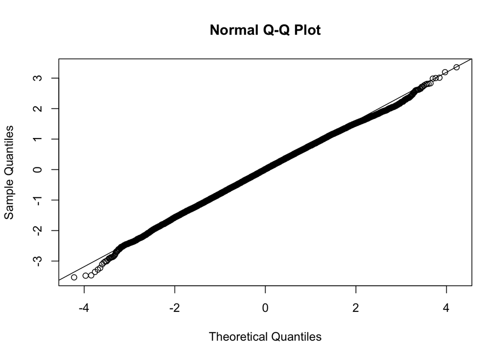

```r
# plot qqplot
qqnorm(resid(resc))
qqline(resid(resc))
```

We can see that the model has good fit result according to the qqplot and residuals vs. fitted values plot.

```r
library(stargazer)
stargazer(resc, type = "text",
          digits = 3,
          star.cutoffs = c(0.05, 0.01, 0.001),
          digit.separator = "")
```

```
##
## =================================================
##                          Dependent variable:
##                     -----------------------------
##                               pm2.5_log
## -------------------------------------------------
## year                           -0.004
##                                (0.003)
##
## month                         -0.021***
##                                (0.001)
##
## day                           0.006***
##                               (0.0004)
##
## hour                          0.013***
##                                (0.002)
##
## DEWP                          0.060***
##                                (0.001)
##
## TEMP                          -0.078***
##                                (0.001)
##
## PRES                          -0.020***
##                                (0.001)
##
## Is                            -0.031***
##                                (0.005)
##
## Ir                            -0.078***
##                                (0.003)
##
## Constant                      32.760***
##                                (5.532)
##
## -------------------------------------------------
## Observations                    41441
## Log Likelihood               -48698.410
## Akaike Inf. Crit.             97430.820
## Bayesian Inf. Crit.           97577.560
## =================================================
## Note:               *p<0.05; **p<0.01; ***p<0.001
```

From the table we can see only year is not significant, which is not the same conclusion as we derive from the first part.

```r
BIC(res, resc)
```

```
##      df      BIC
## res  17 97386.44
## resc 17 97577.56
```

The result is close and regression using **lme4** has rather smaller BIC.

### Python

```python
import statsmodels.api as sm
import statsmodels.formula.api as smf
import pandas as pd
import numpy as np
AQ = pd.read_csv('Beijing.csv')
dic = {1: "Winter",
       2: "Winter",
       3: "Spring",
       4: "Spring",
       5: "Spring",
       6: "Summer",
       7: "Summer",
       8: "Summer",
       9: "Fall",
       10: "Fall",
       11: "Fall",
       12: "Winter"}
AQ['season'] = AQ['month'].map(dic)
AQ = AQ.dropna()
AQ = AQ[AQ['pm2.5'] > 0]
AQ['pm25_log'] = np.log(AQ['pm2.5'])
AQ_cv = AQ[AQ['cbwd'] == 'cv']
AQ_cv = AQ_cv[(AQ_cv['pm25_log'] > 2.2) & (AQ_cv['pm25_log'] < 6.8)]
AQ_NE = AQ[AQ['cbwd'] == 'NE']
AQ_NE = AQ_NE[(AQ_NE['pm25_log'] > 0.5)]
AQ_NW = AQ[AQ['cbwd'] == 'NW']
AQ_NW = AQ_NW[(AQ_NW['pm25_log'] > 0.5)]
AQ_SE = AQ[AQ['cbwd'] == 'SE']
AQ_SE.sort_values(['pm25_log'], ascending=[False])
AQ_SE = AQ_SE[(AQ_SE['pm25_log'] > 0.5) & (AQ_SE['pm25_log'] < 6.291569)]
AQ_new = pd.concat([AQ_cv, AQ_NE, AQ_NW, AQ_SE])
mixed = smf.mixedlm("pm25_log ~ year+month+day+hour+DEWP+TEMP+PRES+Is+Ir", AQ_new, groups = AQ_new["cbwd"], re_formula="~hour+PRES")
mixed_fit = mixed.fit()
print(mixed_fit.summary())
```

Here is the output of the Linear Mixed Effect Model in Python. The result is close to the results from the two packages used in R.

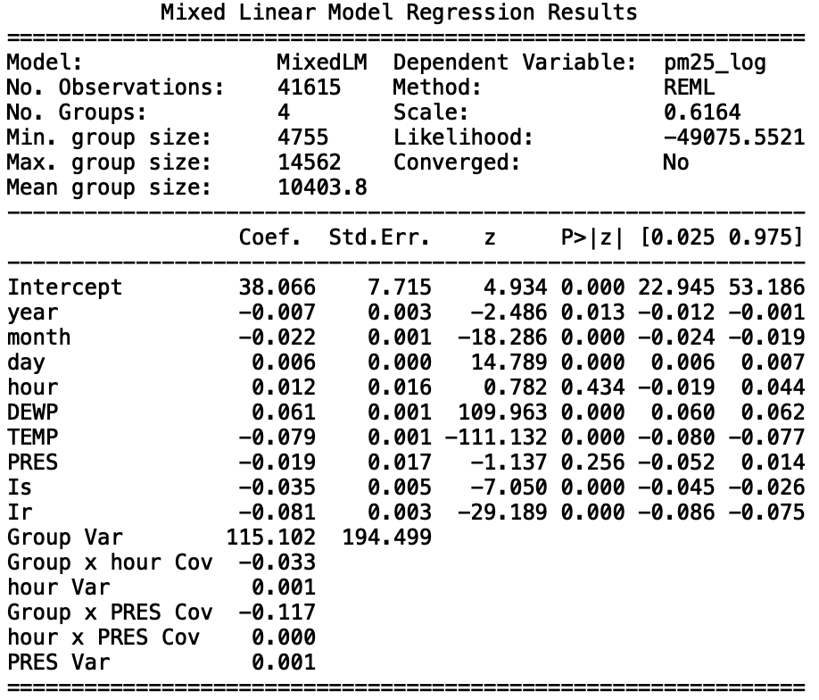